# FINANCE DATA PROJECT

### Import necessary packages

```python
import pandas as pd
import numpy as np
import datetime
import matplotlib.pyplot as plt
import seaborn as sns
import yfinance as yf
%matplotlib inline
sns.set()
```

### Get the stock data

- Bank of America
- CitiGroup
- Capital One
- JPMorgan Chase
- Wells Fargo
- Keycorp

```python
start = datetime.datetime(2006,1,1)
end = datetime.date.today()
```

```python
bank_stocks = yf.download("BAC C COF JPM WFC KEY", start=start, end=end, group_by='ticker')
```

```
[*********************100%***********************]  6 of 6 completed
```

```python
bank_stocks.columns.names = ['Bank Ticker', 'Stock Info']
```

```python
ticker = ['BAC', 'C', 'COF', 'JPM', 'KEY', 'WFC']
```

### Take a look on the bank_stocks data.

```python
bank_stocks.head()
```

| Bank Ticker Stock Info Date | C Open | C High | C Low | C Close | C Adj Close | C Volume | BAC Open | BAC High | BAC Low | BAC Close | ... | KEY Low | KEY Close | KEY Adj Close | KEY Volume | WFC Open | WFC High | WFC Low | WFC Close | WFC Adj Close | WFC Volume |
| --- | --- | --- | --- | --- | --- | --- | --- | --- | --- | --- | --- | --- | --- | --- | --- | --- | --- | --- | --- | --- | --- |
| 2006-01-03 | 490.000000 | 493.799988 | 481.100006 | 492.899994 | 370.934509 | 1537600 | 46.919998 | 47.180000 | 46.150002 | 47.080002 | ... | 32.900002 | 33.669998 | 21.695471 | 1847100 | 31.600000 | 31.975000 | 31.195000 | 31.900000 | 20.523809 | 11016400 |
| 2006-01-04 | 488.600006 | 491.000000 | 483.500000 | 483.799988 | 364.086212 | 1870960 | 47.000000 | 47.240002 | 46.450001 | 46.580002 | ... | 33.459999 | 33.880001 | 21.830795 | 1815500 | 31.799999 | 31.820000 | 31.365000 | 31.530001 | 20.285755 | 10870000 |
| 2006-01-05 | 484.399994 | 487.799988 | 484.000000 | 486.200012 | 365.892365 | 1143160 | 46.580002 | 46.830002 | 46.320000 | 46.639999 | ... | 33.730000 | 34.040001 | 21.933891 | 2057000 | 31.500000 | 31.555000 | 31.309999 | 31.495001 | 20.263241 | 10158000 |
| 2006-01-06 | 488.799988 | 489.000000 | 482.000000 | 486.200012 | 365.892365 | 1370210 | 46.799999 | 46.910000 | 46.349998 | 46.570000 | ... | 33.689999 | 34.049999 | 21.940325 | 1290000 | 31.580000 | 31.775000 | 31.385000 | 31.680000 | 20.382265 | 8403800 |
| 2006-01-09 | 486.000000 | 487.399994 | 483.000000 | 483.899994 | 364.161621 | 1680740 | 46.720001 | 46.970001 | 46.360001 | 46.599998 | ... | 33.799999 | 34.090000 | 21.966105 | 997500 | 31.674999 | 31.825001 | 31.555000 | 31.674999 | 20.379047 | 5619600 |

5 rows × 36 columns

## Find the max close price for each bank's stock

Maximum closing price:

```python
for tick in ticker:
    print(tick, bank_stocks[tick]['Close'].max().round(5))
```

```
BAC 54.9
C 564.09998
COF 166.28999
JPM 166.44
KEY 39.79
WFC 65.93
```

Minimum closing price:

```python
bank_stocks.xs(key='Close', axis=1, level='Stock Info').min()
```

```
Bank Ticker
C      10.20
BAC     3.14
JPM    15.90
COF     8.31
KEY     4.60
WFC     8.12
dtype: float64
```

## Create a new empty DataFrame called returns. This df will contain the returns for each bank's stock.

```python
returns = pd.DataFrame()
```

```python
for tick in ticker:
    returns[tick + ' Return'] = bank_stocks[tick]['Close'].pct_change()
```

Here is the brief overview of returns dataset.

```python
returns.tail()
```

| Date | BAC Return | C Return | COF Return | JPM Return | KEY Return | WFC Return |
| --- | --- | --- | --- | --- | --- | --- |
| 2021-08-02 | -0.010428 | 0.001627 | -0.009895 | -0.004019 | -0.006104 | -0.003265 |
| 2021-08-03 | 0.015543 | 0.016979 | 0.008307 | 0.011378 | 0.024053 | 0.022712 |
| 2021-08-04 | -0.007263 | -0.005226 | -0.001487 | -0.010792 | -0.018991 | -0.014521 |
| 2021-08-05 | 0.019598 | 0.017075 | 0.012408 | 0.012629 | 0.013754 | 0.018202 |
| 2021-08-06 | 0.028960 | 0.019802 | 0.016913 | 0.028404 | 0.021608 | 0.037880 |

## Create a pairplot using seaborn of the returns dataframe.

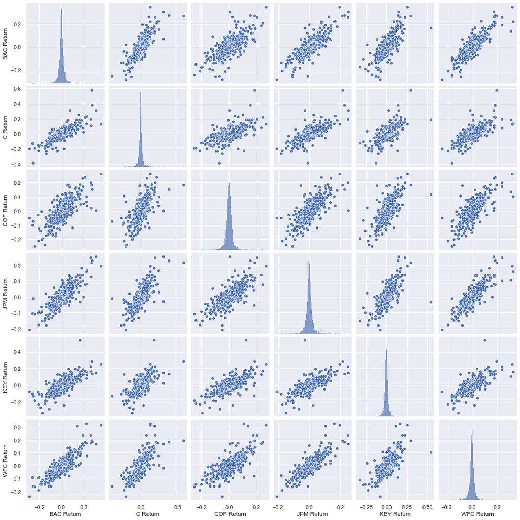

```python
sns.pairplot(returns[1:])
```

## Using the returns dataframe, figure out on what dates each bank stock had the best and worst single day returns.

```python
returns.idxmin()
```

```
BAC Return   2009-01-20
C Return     2009-02-27
COF Return   2009-04-20
JPM Return   2009-01-20
KEY Return   2008-09-29
WFC Return   2009-01-20
dtype: datetime64[ns]
```

```python
returns.idxmax()
```

```
BAC Return   2009-04-09
C Return     2008-11-24
COF Return   2009-04-09
JPM Return   2009-01-21
KEY Return   2008-10-14
WFC Return   2008-07-16
dtype: datetime64[ns]
```

Standard Deviation of the returns over the time period.

```python
returns.std()
```

```
BAC Return    0.032037
C Return      0.033917
COF Return    0.029581
JPM Return    0.024846
KEY Return    0.032525
WFC Return    0.027333
dtype: float64
```

Standard Deviation of the returns for the year 2019.

```python
returns.loc['2019-01-01':'2019-12-31'].std()
```

```
BAC Return    0.014566
C Return      0.015354
COF Return    0.015220
JPM Return    0.011869
KEY Return    0.016226
WFC Return    0.012450
dtype: float64
```

Stock return with highest deviation is considered the riskiest because the price of that particular stock has higher volatality compared to the other.

## Create a distplot using seaborn of the 2015 for KeyGroup

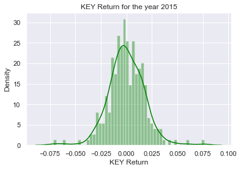

```python
sns.distplot(returns.loc['2015-01-01':'2015-12-31']['KEY Return'], color='green', bins=50 )
plt.title("KEY Return for the year 2015")
```

## Create a distplot using seaborn of the 2008 for CitiGroup

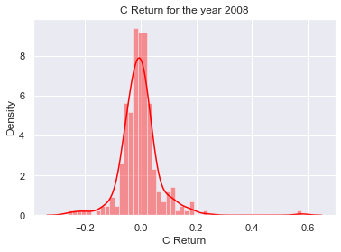

```python
sns.distplot(returns.loc['2008-01-01':'2008-12-31']['C Return'], color='red', bins=50 )
plt.title("C Return for the year 2008")
```

## Imports

Now we will import plotly and cufflinks as additional visualization modules.

```python
sns.set_style('whitegrid')

import plotly
import cufflinks as cf
cf.go_offline()

from plotly.offline import init_notebook_mode
init_notebook_mode(connected=True)
```

## Create a line plot showing Close price for each bank.

The plot below shows the Closing price for each stock from 2006 to 2016. For the first graph, we use pandas built in plotting library while the second graph we use the plotly library.

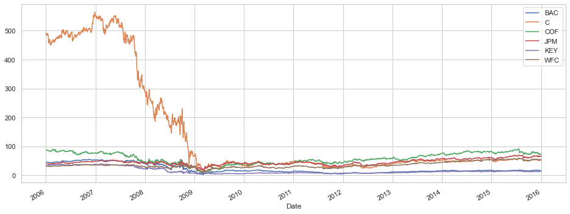

```python
for tick in ticker:
    bank_stocks.loc['2006-01-01':'2015-12-31'][tick]['Close'].plot(label=tick, figsize=(16,6))
plt.legend()
```

```python
bank_stocks.loc['2006-01-01':'2015-12-31'].xs(key = 'Close', axis=1, level='Stock Info').iplot()
```

[interactive chart not shown]

# Moving Averages

### Plot the 30 day average against the Close Price for BofA stock for the year 2008

```python
bank_stocks['BAC']
```

| Stock Info Date | Open | High | Low | Close | Adj Close | Volume |
| --- | --- | --- | --- | --- | --- | --- |
| 2006-01-03 | 46.919998 | 47.180000 | 46.150002 | 47.080002 | 34.280807 | 16296700 |
| 2006-01-04 | 47.000000 | 47.240002 | 46.450001 | 46.580002 | 33.916729 | 17757900 |
| 2006-01-05 | 46.580002 | 46.830002 | 46.320000 | 46.639999 | 33.960411 | 14970700 |
| 2006-01-06 | 46.799999 | 46.910000 | 46.349998 | 46.570000 | 33.909451 | 12599800 |
| 2006-01-09 | 46.720001 | 46.970001 | 46.360001 | 46.599998 | 33.931290 | 15619400 |
| ... | ... | ... | ... | ... | ... | ... |
| 2021-08-02 | 38.400002 | 38.950001 | 37.910000 | 37.959999 | 37.959999 | 49894000 |
| 2021-08-03 | 38.060001 | 38.630001 | 37.549999 | 38.549999 | 38.549999 | 39644700 |
| 2021-08-04 | 38.029999 | 38.770000 | 37.860001 | 38.270000 | 38.270000 | 42289800 |
| 2021-08-05 | 38.570000 | 39.060001 | 38.549999 | 39.020000 | 39.020000 | 34754500 |
| 2021-08-06 | 39.470001 | 40.410000 | 39.470001 | 40.150002 | 40.150002 | 58000800 |

3926 rows × 6 columns

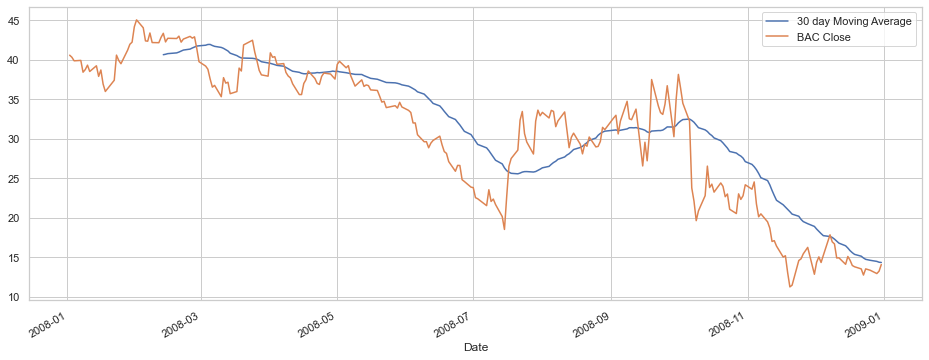

```python
plt.figure(figsize=(16,6))
bank_stocks['BAC']['Close'].loc['2008-01-01':'2008-12-31'].rolling(window=30).mean().plot(label='30 day Moving Average')
bank_stocks['BAC']['Close'].loc['2008-01-01':'2008-12-31'].plot(label='BAC Close')
plt.legend()
```

### Create a heatmap of the correlation between the stock Close Price.

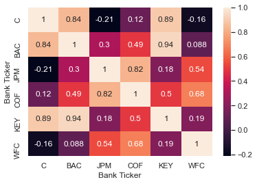

```python
sns.heatmap(bank_stocks.xs(key='Close', axis=1, level='Stock Info').corr(), annot=True)
```

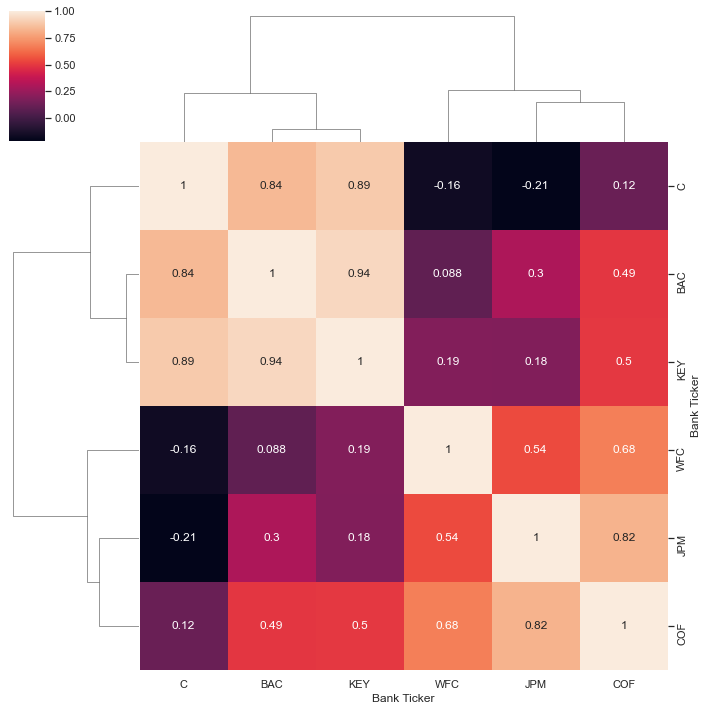

```python
sns.clustermap(bank_stocks.xs(key='Close', axis=1, level='Stock Info').corr(), annot=True)
```

### Create a candle plot of BofA stock from Jan 1st 2015 to Jan 1st 2016

```python
bank_stocks.loc['2015-01-01':'2016-01-01']['BAC'].iplot(kind='candle')
```

[interactive chart not shown]